# Final Project

Justin Maynard, Eric Newton, Maia Griffith

2023-12-12

```
## [1] "/home/guest/ENV872/EDE_Final_Project"
```

# Rationale and Research Questions

Many countries around the world, including the United States, have committed to protecting 30% of their land and water, including protecting 30% of their ocean, by 2030 by 2030. Current estimates reveal that the USA appears to be doing quite well, with [around 26%](https://www.frontiersin.org/articles/10.3389/fmars.2022.849927/full) of our oceans and waters currently under some type of protection. However, not all of the protected areas provide the same level of conservation or management. Understanding and visualizing the growth of MPAs and analyzing their protective strength in the United States over time is a critical piece in achieving the 30x30 goal.

We decided to focus on MPAs before and after an executive order was released from President Bill Clinton in 2000, which aimed to improve the protections provided from MPAs.

From [Executive Order 13158](https://www.govinfo.gov/content/pkg/WCPD-2000-05-29/pdf/WCPD-2000-05-29-Pg1230.pdf): “To this end, the purpose of this order is to, consistent with domestic and international law: (a) **strengthen** the management, protection, and conservation of existing marine protected areas and **establish new or expanded MPAs**; (b) develop a scientifically based, comprehensive national **system of MPAs** representing diverse U.S. marine ecosystems, and the Nation’s natural and cultural resources; and (c) **avoid causing harm** to MPAs through federally conducted, approved, or funded activities.”

This landmark declaration helped spur the future creation of large and important MPAs in subsequent years. Our dataset is from NOAA’s list of Marine Protected Areas in the United States, which includes information on the size, location, type, and status of MPAs.

## Research Questions

1. What is the comparison of different Levels of Protection and Management Plans across all MPAs overtime?
2. How do MPAs from pre-2000 compare to post-2000 in terms of Level of Protection and Management Plan?
3. Where are the MPAs and how can we visualize it across the USA?

# Dataset Information

The dataset from NOAA was created by NOAA using information from state and federal agencies dealing with the creation and management of MPAs in the USA. Almost all the MPAs had all the information populated fully, and the metadata included descriptions of each item. The metadata was key in creating the rankings for protections later on. To process the data, we selected only the columns we were going to use in our analysis: OBJECTID, Site.Name, State, Level.of.Protection, Management.Plan, Year.Established, Marine.Status, Area..km2., Marine.Area..km2., Percent.Area.Marine, No.Take.Area..km2., Longitude, Latitude. Then we filtered out the few rows without a Year.Established, formatted our Year.Established as a date, and then renamed a few columns for ease of coding. The basic structure is outline below (Table 1).

Table 1: Basic Dataset Information

| Detail | Description |
| --- | --- |
| Data Source | [NOAA Marine Protected Area Inventory](https://marineprotectedareas.noaa.gov/dataanalysis/mpainventory/) |
| Metadata Source | [ONMS Metadata Library](https://www.fisheries.noaa.gov/inport/item/69507) |
| Variables Used | OBJECTID, Site.Name, State, Level.of.Protection, Management.Plan, Year.Established, Marine.Status, Area..km2., Marine.Area..km2., Percent.Area.Marine, No.Take.Area..km2., Longitude, Latitude |
| Data Range | 1903 to 2022 |

# Exploratory Analysis

Before analyzing the data, wanted to get an idea of the data we were working with, and created a simple visualization of the number MPAs created per year (see Figure 1 below). This showed us that there is quite a lot of variance among the years.

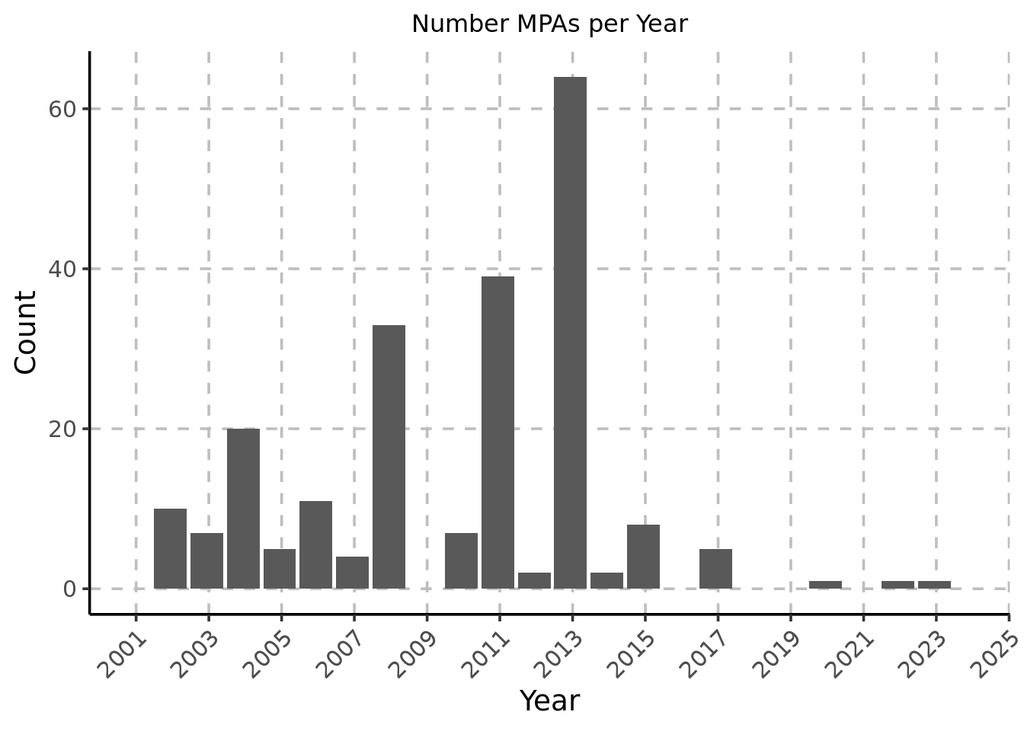

Figure 1: Preliminary data visualiztion to understand our data, showing the number of MPAs created per year in the United States.

Understanding and visualizing the growth of MPAs in the United States over time is a critical piece in achieving the 30x30 goal. The following figures show the cumulative growth over time of the number of MPAs (Figure 2) and the total area of MPAs (Figure 3).

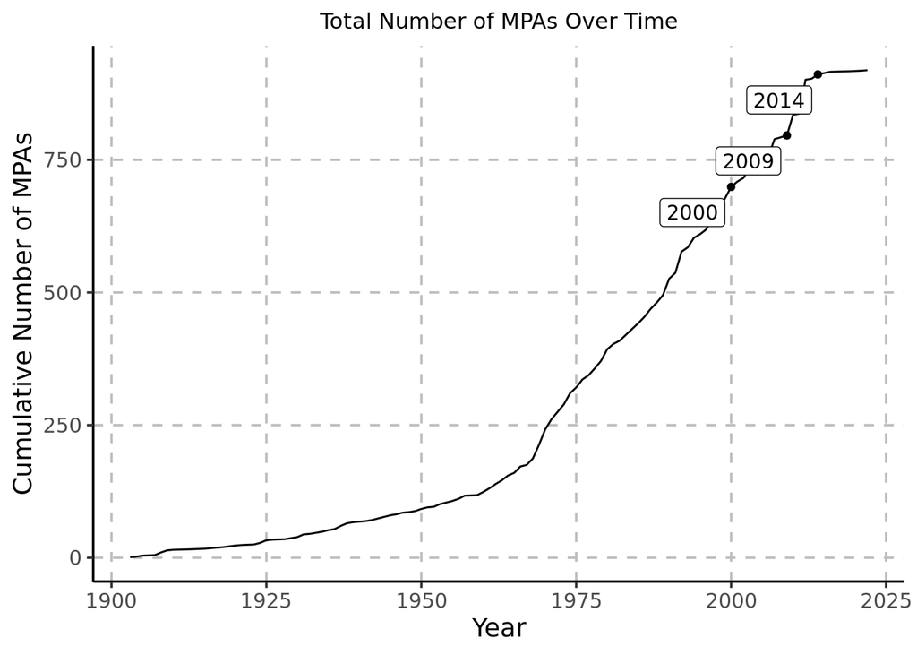

Figure 2: Plot showing the cumulative sum of the total number of MPAs in the United States over time.

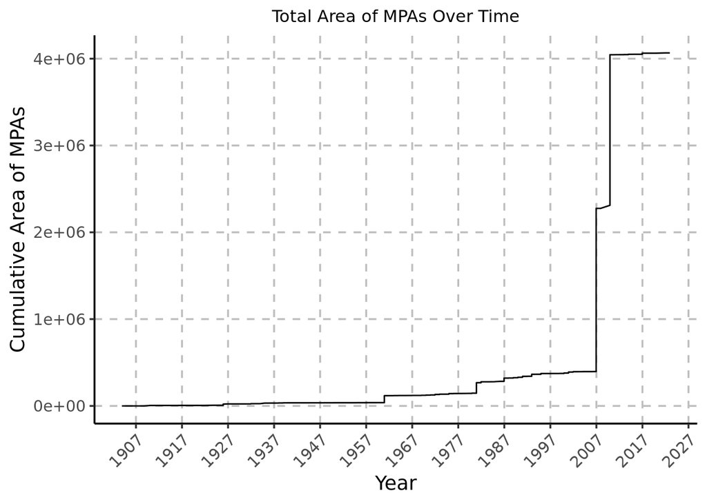

Figure 3: Plot showing the cumulative sum of total MPA area in the United States over time.

These plots reveal a strong upward trend of MPAs both in number and in area. However, this does not tell us anything about the strength of the MPAs being created. Our analysis will focus on visualizing and testing to see if there was in fact a difference in park strength before and after President Clinton’s executive order.

# Analysis

Each question of our analysis required more wrangling of the data before creating plots, running tests, and making maps.

## Question 1:

**What is the comparison of different Levels of Protection and Management Plans across all MPAs overtime?**

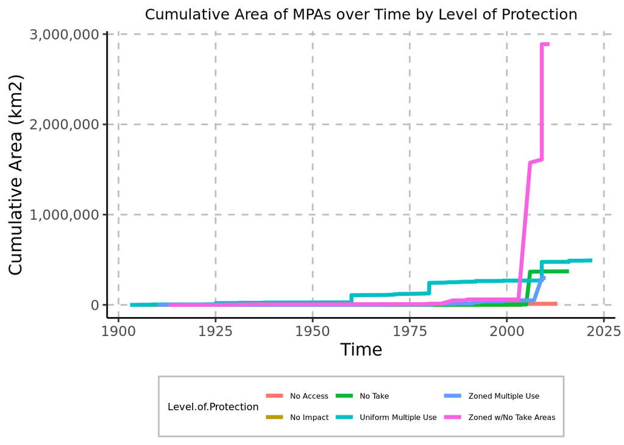

Figure 4: Plot showing the cumulative sum of MPA area over time by Level of Protection.

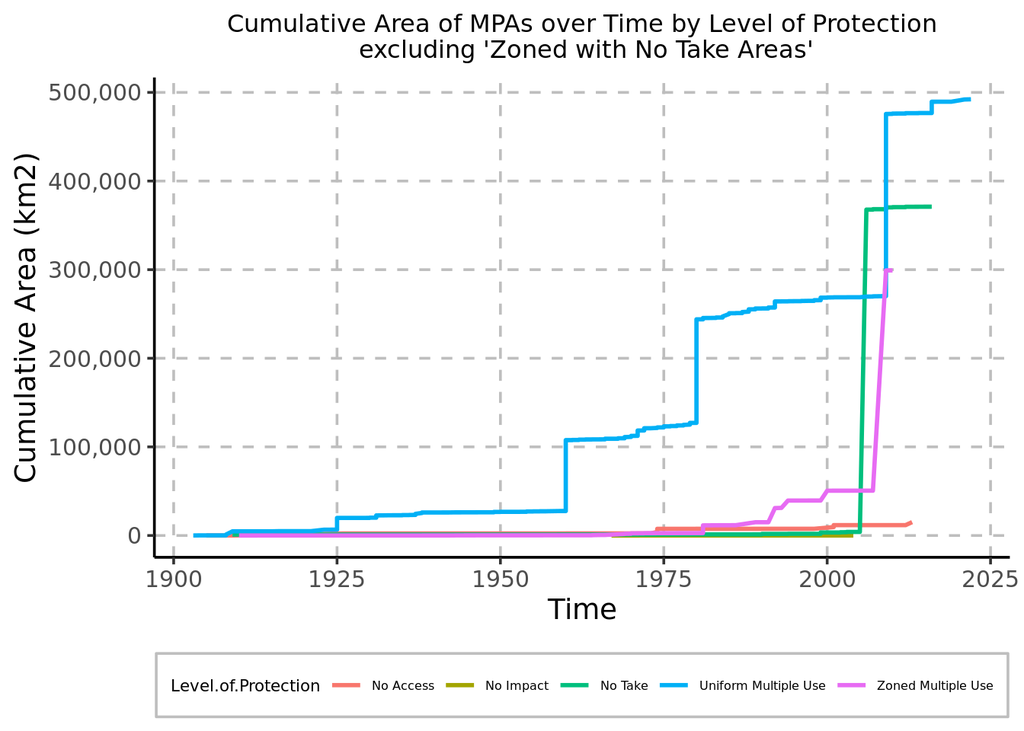

Figure 5: Plot showing cumulative area of MPAs over time by Level of Protection with MPAs Zoned with No Take Areas omitted.

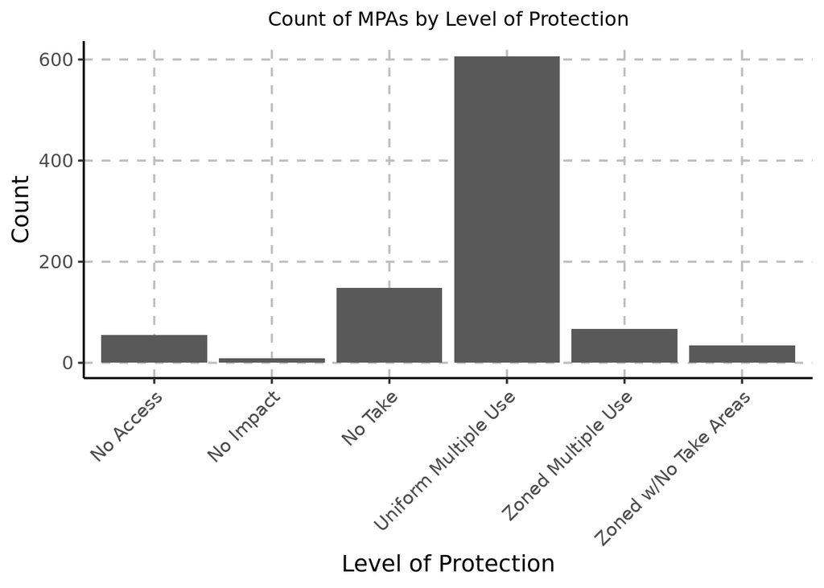

Figure 6: Count of MPAs in the United States by Level of Protection.

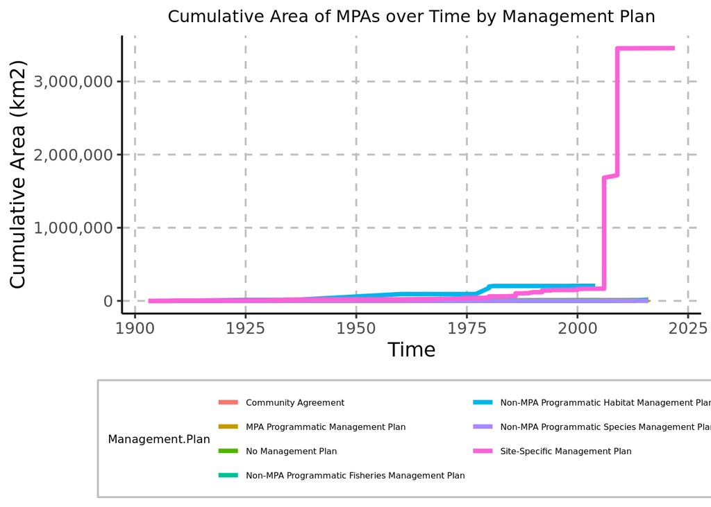

Figure 7: Plot showing the cumulative sum of MPA area over time by Management Plan

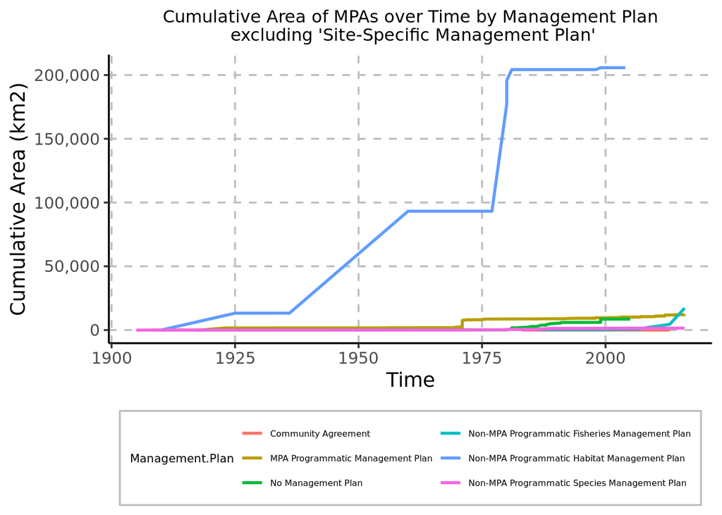

Figure 8: Plot showing the cumulative sum of MPA area over time by Management Area with Site-Specific Management Plans omitted.

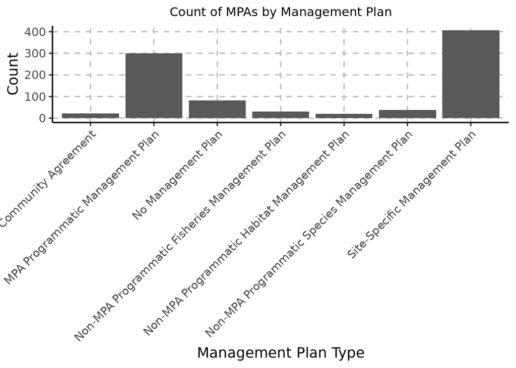

## Question 2:

**How do MPAs from pre-2000 compare to post-2000 in terms of Level of Protection and Management Plan?**

```
## [1] "No Access"             "No Impact"             "No Take"
## [4] "Uniform Multiple Use"  "Zoned Multiple Use"    "Zoned w/No Take Areas"
```

```
##  [1] ""
##  [2] "Community Agreement"
##  [3] "MPA Management Plan"
##  [4] "MPA Programmatic Management Plan"
##  [5] "No Management Plan"
##  [6] "Non-MPA Programmatic Fisheries Management Plan"
##  [7] "Non-MPA Programmatic Habitat Management Plan"
##  [8] "Non-MPA Programmatic Species Management Plan"
##  [9] "Non-MPA Programmatic Species Management Plan\n"
## [10] "Site-Specific Management Plan"
```

### Ranking Protections

To assign rankings for each Level of Protection and Management Plan, the metadata was used to compare the various types. Low numbers are lower protections, and high numbers are higher protections. Information used along with our rankings (in parenthesis) are below.

**Management Level (1-Low, 7-High):** (1) No Management Plan: No management plan has been developed for the site, or the management plan is still in draft form

2. Community Agreement: A verbal or written community agreement has been reached for the management of the site
3. Non-MPA Programmatic Species Management Plan: A species management plan has been developed, which includes the management of the site
4. Non-MPA Programmatic Fisheries Management Plan: A fisheries management plan has been developed, which includes the management of the site
5. Non-MPA Programmatic Habitat Management Plan: A habitat management plan has been developed, which includes the management of the site
6. MPA Programmatic Management Plan: A management plan has been developed for a broader MPA program, which includes the site
7. Site-Specific Management Plan: A management plan has been developed specifically for the site

These rankings were then assigned to each MPA.

### Q2 Plots

Before performing the t-tests, three plots for visualization of the data were created. These help show the difference between the pre- and post-2000 groups to get a better idea of the data.

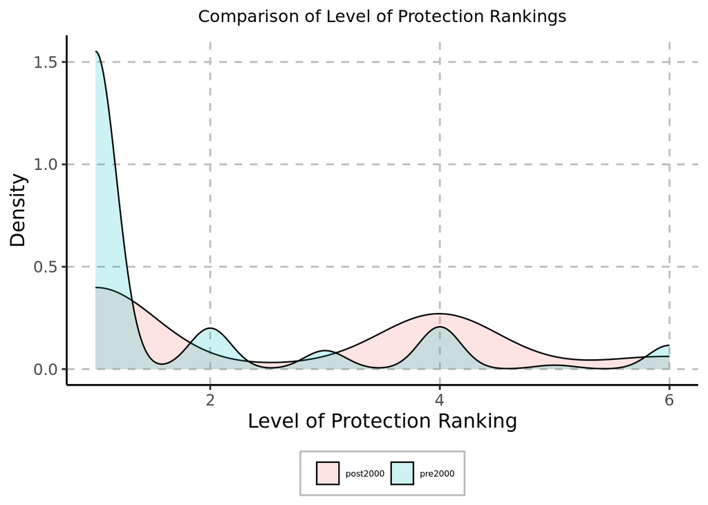

Figure 10: Plot showing variation in Levels of Protection in the pre-2000 and post-2000 groups.

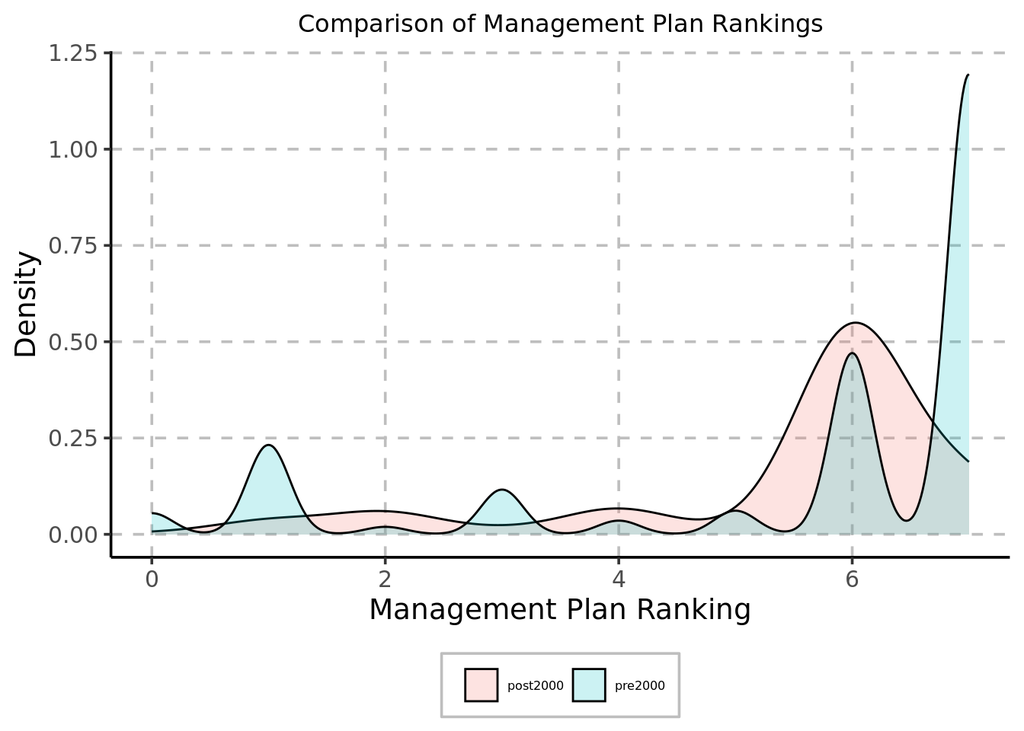

Figure 11: Plot showing variation in Management Plans in the pre-2000 and post-2000 groups.

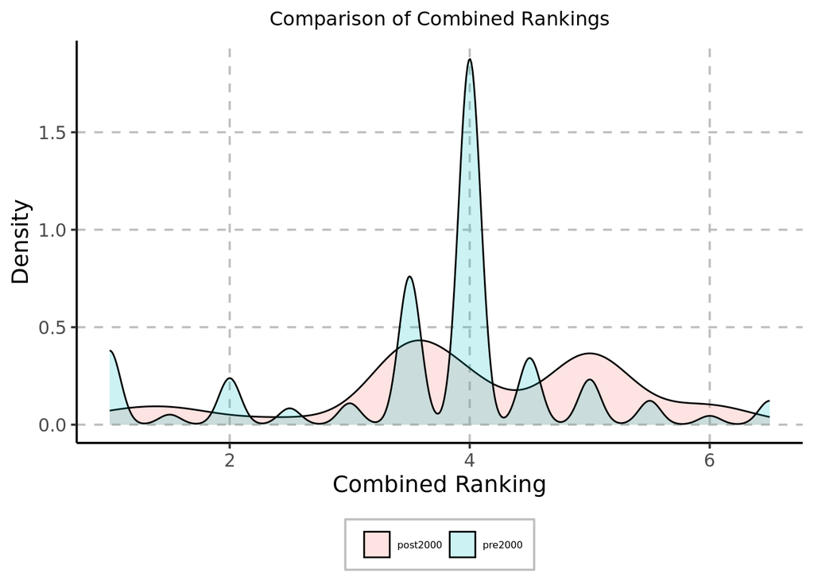

Figure 12: Plot showing variation in combined ranking scores in the pre-2000 and post-2000 groups.

Next, perform the Welch Two Sample t-test to compare means before and after 2000 for the Level of Protection, Management Plan, and the Combined Average Ranking. For **Levels of Protection**, the t-test reveals that in the post-2000 era, MPAs were given significantly higher Levels of Protection than before 2000 (df = 362.42, p-value = 4.593e-10). For **Management Plans**, no significant difference was found between the two time periods (df = 574, p-value = 0.2563). However, when using the **combined ranking** for the MPAs, which took the average score between Level of Protection and Management Plan, the post-2000 group still had significantly higher protections than the pre-2000 group (df = 403.16, p-value = 0.0006872).

## Question 3:

Where are the MPAs and how can we visualize it across the USA?

View the interactive map showing MPAs as points at https://jwmaynard.shinyapps.io/ShinyMapsFinal/ or navigate to Code/ShinyMapsFinalAreas and run app.R to view MPAs as shape files.

To visualize MPAs across the United States and it’s territories, RShiny was used. A geodatabase containing raster files of areas covered by MPAs along with information regarding MPAs was used. RShiny was used so users could select the region of the United States they wish to visualize MPAs for, and users could select to filter by management plan or level of protection, allowing users to interactivly undserstand where MPAs exist and what protections they offer.

When looking at where the MPAs are distributed, the majority of them are in the American South or West. 551 MPAs are in the South, and 441 are in the West. Islands in the Pacific Ocean have 150 MPAs, while the Northeast and Midwest have 142 and 43 respectively. Out of the total 1328 represented MPAs from the geodatabase, 678 had site specific management plans, 344 had programmatic management plans, and 105 had no management plans, with other less common management plans also occurring. When looking at the level of protection there are 752 MPAs that are uniform multiple use, 256 that are no take, and 113 that had no level of protection attached. In the South, an overwhelming majority of management plans are site specific (395), while most had a level of protection of uniform multiple use (369). The West has a majority programmatic management plans (216), followed by 126 site-specific management plans. Level of protection from MPAs in the West are mostly uniform multiple use with 213 occurrences, and no take with 146 occurrences. Out of the 150 Pacific MPAs, 75 have site specific management plans, while 35 have programmatic management plans. There are 60 uniform multiple use sites and 25 no take site in the Pacific. Out of the Northeast’s 142 MPAs 64 are site specific and 43 are programmatic management plans. There are 92 uniform multiple use sites and 21 zones multiple use sites in the northeast. In the Midwest there are 19 site specific management plans, but 14 MPAs with no management plans, which is 32% of MPAs in the midwest. 18 of the MPAs in the Midwest are uniform multiple use.

# Summary and Conclusions

To better visualize the change in MPA area over time for other Level of Protection categories and Management Plans, plots were made that omit ‘Zoned with No Take Areas’ MPAs with Site Specific Management Plans. These plots reveal that MPAs with ‘Uniform Multiple Use’ protection, the category we assigned as the lowest Level of Protection, accounted for the second largest cumulative area. Conversely, MPAs with Non-MPA Programmatic Habitat Management Plans make up the second largest cumulative area, a relatively strong Management Plan type.

When comparing pre-2000 and post-2000 ranked Levels of Protection and Management Plans, we can conclude that overall there appears to a significant difference between the two time periods. This means we can reject our null hypothesis and accept our alternative hypothesis that the pre- and post-2000 groups would have different overall protections. We can also infer that the executive order from President Clinton may have helped make this change, although this cannot be 100% confirmed, as correlation does not always mean causation. Further studies into the creation of each MPA should be done to evaluate the reasons behind various Level of Protection and Management Plan choices.

Most MPAs across the United States have a ‘Uniform Multiple Use’ protection level, with many also being ‘No Take.’ There is no large difference between geographic location and protection level, as all regions have ‘Uniform Multiple Use’ as the most common level of protection, and all regions except the Midwest and Northeast have ‘No Take’ as the second most common level of protection. The most common management plan throughout the US is ‘Site-Specific Management Plan,’ followed by ‘MPA Programmatic Management Plan.’ These were the two most common management plans in all regions except for the Midwest, which had ‘Site-Specific Management Plan’ and ‘No Management Plan’ for its two most common.